# Loading and preprocessing the data

## Loading and preprocessing the data

Data is loaded into a data frame from a CSV file.

```r
library(plyr)
library(lubridate)
library(lattice)

data <- read.csv("activity.csv",na.strings="NA")
data$date <- ymd(data$date)
```

## What is mean total number of steps taken per day?

The following is a histogram of the daily steps taken.

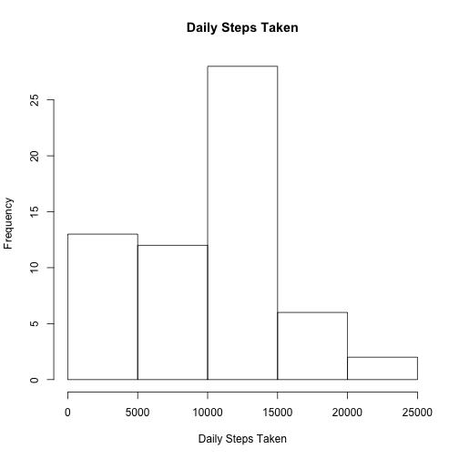

```r
dailySteps <- ddply(data,.(date),summarize,stepsTaken = sum(steps,na.rm=TRUE))

hist(dailySteps$stepsTaken,xlab='Daily Steps Taken',main='Daily Steps Taken')
```

```r
meanDailySteps <- mean(dailySteps$stepsTaken)
medianDailySteps <- median(dailySteps$stepsTaken)
```

The mean number of steps taken daily is 9354.2295082 and the median is 10395.

## What is the average daily activity pattern?

The following is a plot of the daily activity pattern averaged across all the days in the data set.

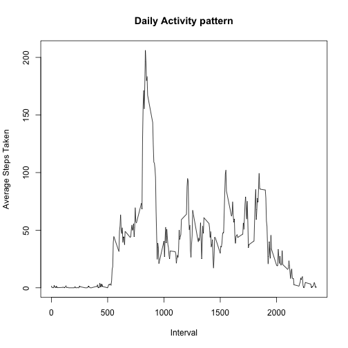

```r
dailyActivityPattern <- ddply(data,.(interval),summarize,meanStepsTaken = mean(steps,na.rm=TRUE))

plot(dailyActivityPattern$interval,dailyActivityPattern$meanStepsTaken,type='l',xlab='Interval',ylab='Average Steps Taken',main='Daily Activity pattern')
```

```r
maxStepsInterval <- dailyActivityPattern[which.max(dailyActivityPattern$meanStepsTaken),1]
```

On average, the interval in which the most steps were taken is 835.

## Imputing missing values

```r
missingValCount <- sum(is.na(data$steps))
```

There are 2304 missing values for steps taken in the data set.

Missing 'steps' values were estimated by taking the average of all non-NA steps data, as follows.

```r
replaceNA <- function(s) {
  if(is.na(s)) {
    s <- mean(data$steps,na.rm=TRUE)
    # s <- dailyActivityPattern[which(dailyActivityPattern$interval==i),2][1]
  }
  s
}

estData <- data
estData$estSteps <- sapply(data$steps,replaceNA)
```

The following is a histogram of the daily steps taken using the estimated steps data.

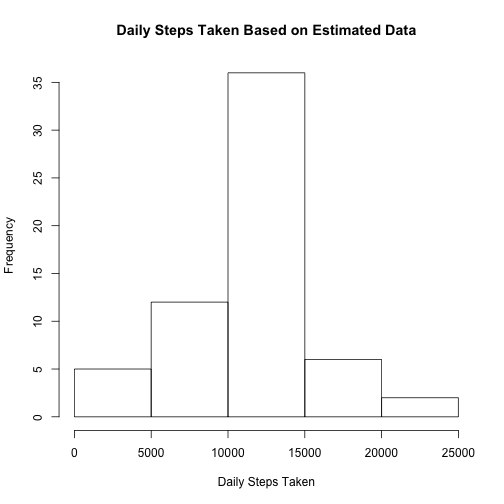

```r
estDailySteps <- ddply(estData,.(date),summarize,stepsTaken = sum(estSteps,na.rm=TRUE))

hist(estDailySteps$stepsTaken,xlab='Daily Steps Taken',main='Daily Steps Taken Based on Estimated Data')
```

```r
estMeanDailySteps <- mean(estDailySteps$stepsTaken)
estMedianDailySteps <- median(estDailySteps$stepsTaken)
```

## Are there differences in activity patterns between weekdays and weekends?

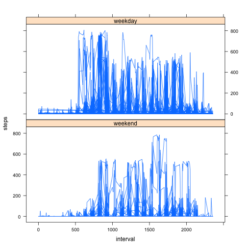

```r
weekends <- c('Saturday','Sunday')

data$isWeekend <- factor((weekdays(data$date) %in% weekends), levels=c(TRUE,FALSE), labels=c('weekend', 'weekday'))

xyplot(steps ~ interval|isWeekend, data=data, layout=c(1,2), type="l")
```